# Data Mining Project (ifood)

In this project, I will conduct data mining on a grocery firm's marketing data to uncover insights and provide marketing recommendations. The project is divided into three main parts:

### Part 1: Customer Segmentation

I will segment the customers into three clusters using hierarchical clustering. This segmentation will be based on:

-Demographic information -Purchasing behaviors -Amount spent in each product category

### Part 2: Regression Analysis

To understand the relationship between the total amount spent by each customer and other variables, I will perform a regression analysis. The regression model will predict how much a customer will spend, adhering to the principles of parsimony by selecting as few variables as possible that still explain the majority of the variance.

### Part 3: Analysis of Spending Differences

By completing these analyses, we will gain valuable insights into customer behavior, which will inform targeted marketing strategies.

```python
import pandas as pd
import numpy as np
import matplotlib.pyplot as plt
import seaborn as sns
from scipy.cluster.hierarchy import dendrogram, linkage
from sklearn.cluster import AgglomerativeClustering
from sklearn.preprocessing import StandardScaler
import statsmodels.api as sm
from statsmodels.stats.outliers_influence import variance_inflation_factor
from statsmodels.formula.api import ols
```

# Read Data

```python
#Read CSV file
df = pd.read_csv("ifood_df.csv")
```

```python
df.info()
```

```
<class 'pandas.core.frame.DataFrame'>
RangeIndex: 2205 entries, 0 to 2204
Data columns (total 39 columns):
 #   Column                Non-Null Count  Dtype
---  ------                --------------  -----
 0   Income                2205 non-null   float64
 1   Kidhome               2205 non-null   int64
 2   Teenhome              2205 non-null   int64
 3   Recency               2205 non-null   int64
 4   MntWines              2205 non-null   int64
 5   MntFruits             2205 non-null   int64
 6   MntMeatProducts       2205 non-null   int64
 7   MntFishProducts       2205 non-null   int64
 8   MntSweetProducts      2205 non-null   int64
 9   MntGoldProds          2205 non-null   int64
```

[output cut: 31 more lines]

# Data Cleaning

```python
#Check data for duplicated data
df.duplicated().sum()
```

```
184
```

184 duplicated information are identified. We will proceed to remove them.

```python
#Drop duplicates
df.drop_duplicates(inplace = True)
```

Fortunately, there are no missing values.

```python
#Check for NAs
df.isna().sum()
```

```
Income                  0
Kidhome                 0
Teenhome                0
Recency                 0
MntWines                0
MntFruits               0
MntMeatProducts         0
MntFishProducts         0
MntSweetProducts        0
MntGoldProds            0
NumDealsPurchases       0
NumWebPurchases         0
NumCatalogPurchases     0
NumStorePurchases       0
NumWebVisitsMonth       0
AcceptedCmp3            0
AcceptedCmp4            0
AcceptedCmp5            0
AcceptedCmp1            0
AcceptedCmp2            0
Complain                0
Z_CostContact           0
Z_Revenue               0
Response                0
Age                     0
Customer_Days           0
marital_Divorced        0
marital_Married         0
marital_Single          0
marital_Together        0
marital_Widow           0
education_2n Cycle      0
education_Basic         0
education_Graduation    0
education_Master        0
education_PhD           0
MntTotal                0
MntRegularProds         0
AcceptedCmpOverall      0
dtype: int64
```

```python
df.head()
```

|  | Income | Kidhome | Teenhome | Recency | MntWines | MntFruits | MntMeatProducts | MntFishProducts | MntSweetProducts | MntGoldProds | ... | marital_Together | marital_Widow | education_2n Cycle | education_Basic | education_Graduation | education_Master | education_PhD | MntTotal | MntRegularProds | AcceptedCmpOverall |
| --- | --- | --- | --- | --- | --- | --- | --- | --- | --- | --- | --- | --- | --- | --- | --- | --- | --- | --- | --- | --- | --- |
| 0 | 58138.0 | 0 | 0 | 58 | 635 | 88 | 546 | 172 | 88 | 88 | ... | 0 | 0 | 0 | 0 | 1 | 0 | 0 | 1529 | 1441 | 0 |
| 1 | 46344.0 | 1 | 1 | 38 | 11 | 1 | 6 | 2 | 1 | 6 | ... | 0 | 0 | 0 | 0 | 1 | 0 | 0 | 21 | 15 | 0 |
| 2 | 71613.0 | 0 | 0 | 26 | 426 | 49 | 127 | 111 | 21 | 42 | ... | 1 | 0 | 0 | 0 | 1 | 0 | 0 | 734 | 692 | 0 |
| 3 | 26646.0 | 1 | 0 | 26 | 11 | 4 | 20 | 10 | 3 | 5 | ... | 1 | 0 | 0 | 0 | 1 | 0 | 0 | 48 | 43 | 0 |
| 4 | 58293.0 | 1 | 0 | 94 | 173 | 43 | 118 | 46 | 27 | 15 | ... | 0 | 0 | 0 | 0 | 0 | 0 | 1 | 407 | 392 | 0 |

5 rows × 39 columns

```python
df.nunique()
```

```
Income                  1963
Kidhome                    3
Teenhome                   3
Recency                  100
MntWines                 775
MntFruits                158
MntMeatProducts          551
MntFishProducts          182
MntSweetProducts         176
MntGoldProds             212
NumDealsPurchases         15
NumWebPurchases           15
NumCatalogPurchases       13
NumStorePurchases         14
NumWebVisitsMonth         16
AcceptedCmp3               2
AcceptedCmp4               2
AcceptedCmp5               2
AcceptedCmp1               2
AcceptedCmp2               2
Complain                   2
Z_CostContact              1
Z_Revenue                  1
Response                   2
Age                       56
Customer_Days            662
marital_Divorced           2
marital_Married            2
marital_Single             2
marital_Together           2
marital_Widow              2
education_2n Cycle         2
education_Basic            2
education_Graduation       2
education_Master           2
education_PhD              2
MntTotal                 897
MntRegularProds          974
AcceptedCmpOverall         5
dtype: int64
```

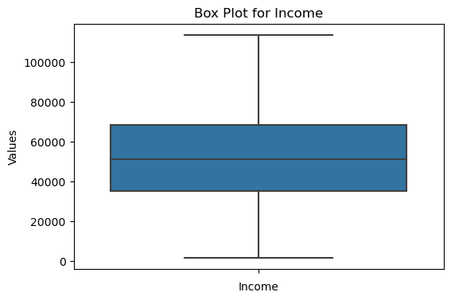

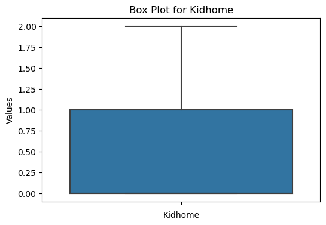

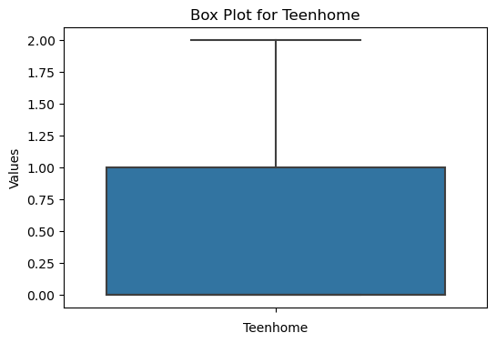

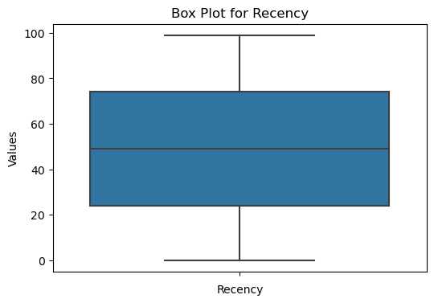

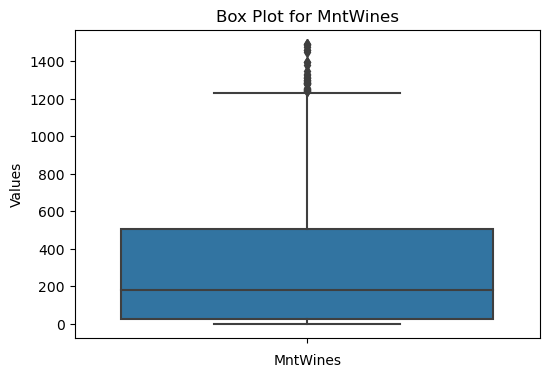

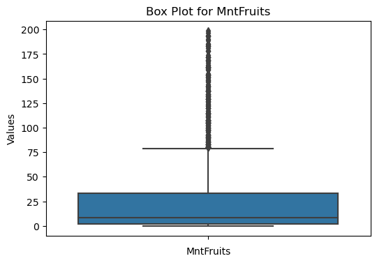

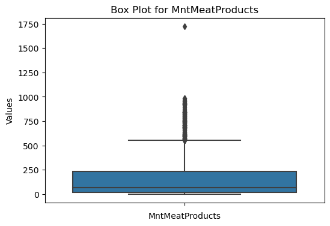

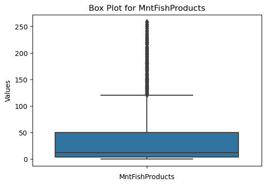

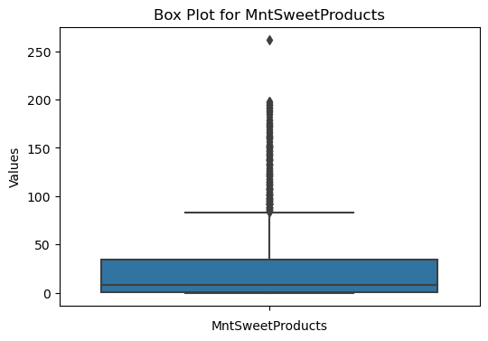

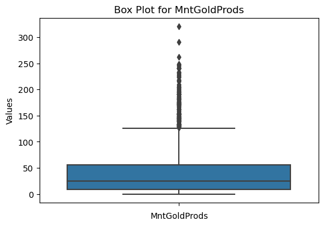

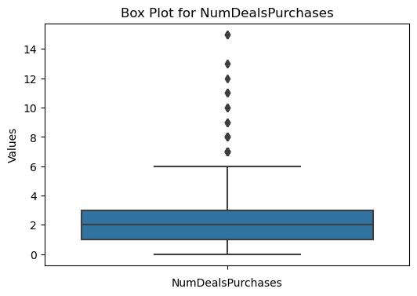

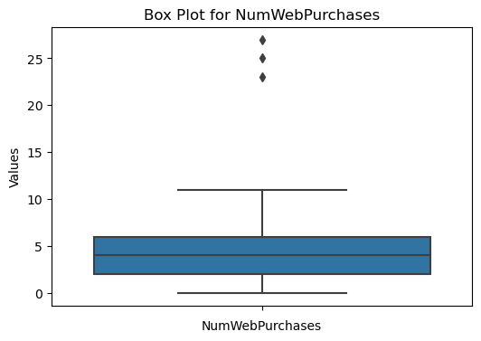

[27 more figures not shown]

```python
for column in df.columns:
    plt.figure(figsize=(6, 4))
    sns.boxplot(y=df[column])
    plt.title(f'Box Plot for {column}')
    plt.xlabel(column)
    plt.ylabel('Values')
    plt.show()
```

We will generate boxplots for each variable to identify any extreme outliers that require our attention. Upon reviewing the boxplots, we observe outliers in the amount spent variables. However, these outliers appear to be genuine and not overly extreme or indicative of data errors. Therefore, we will retain this data for our analysis.

# Data Engineering

We will perform data engineering to create new variables for our analysis. Additionally, we will make certain adjustments to the data. For instance, we will convert the education level into an ordinal variable to facilitate its use in our subsequent analysis.

```python
#We create a new variable and assign the education level of each customer as value.
df["educationlevel"] = 0

def assign_education_level(row):
    if row['education_PhD'] == 1:
        return 5
    elif row['education_Master'] == 1:
        return 4
    elif row['education_2n Cycle'] == 1:
        return 3
    elif row['education_Graduation'] == 1:
        return 2
    elif row['education_Basic'] == 1:
        return 1
    else:
        return 0

df['educationlevel'] = df.apply(assign_education_level, axis=1)
```

To ensure that there are enough observations for each group in our analysis, we will perform a quick computation of value counts to understand the frequency of each group. This will help us verify that our data is sufficiently balanced and that we have an adequate number of observations for reliable statistical analysis.

```python
df["educationlevel"].value_counts()
```

```
educationlevel
2    1015
5     439
4     335
3     183
1      49
Name: count, dtype: int64
```

```python
#New variable that describes the total number of children each customer has.
df["Totalkidsnum"] = df["Kidhome"] + df["Teenhome"]
```

```python
#New variable that describes the total amount spent for each customers.
df["Total_Mnt"] = df["MntWines"] + df["MntFruits"] + df["MntMeatProducts"] + df["MntFishProducts"] + df["MntSweetProducts"] + df["MntGoldProds"]
```

# Hierarchical Cluster Analysis

Now that I have clean the data, I will proceed to perform Hierarchical Cluster analysis. Hierarchical clustering is a method that builds clusters by measuring dissimilarities between data points and progressively merging them until a desired number of clusters is achieved.

The clustering will involve 3 steps, -Identifying the number of clusters through the observation of vertical height of dendrogram. -Clustering the dataset. -Examing the characteristics of each cluster.

We will apply Ward's method, which minimizes variance within clusters, and compute distances between points using Euclidean distance.

```python
#Selecting the required variables for our analysis.
selected_columns = ["Income",
              "Totalkidsnum",
              "Age",
              "educationlevel",
              "MntWines",
              "MntFruits",
              "MntMeatProducts",
              "MntFishProducts",
              "MntSweetProducts",
              "MntGoldProds",
              "NumDealsPurchases",
              "NumWebPurchases",
              "NumCatalogPurchases",
              "NumStorePurchases",
              "NumWebVisitsMonth"]
```

```python
#To ensure that variables with higher measures do not dominate the data, we will copy the dataset and scale the variables.
#This will also ensure that the analysis reliability is enhanced.
df_scaled = df.copy()
df_scaled = df_scaled[selected_columns]
```

```python
df_scaled.head()
```

|  | Income | Totalkidsnum | Age | educationlevel | MntWines | MntFruits | MntMeatProducts | MntFishProducts | MntSweetProducts | MntGoldProds | NumDealsPurchases | NumWebPurchases | NumCatalogPurchases | NumStorePurchases | NumWebVisitsMonth |
| --- | --- | --- | --- | --- | --- | --- | --- | --- | --- | --- | --- | --- | --- | --- | --- |
| 0 | 58138.0 | 0 | 63 | 2 | 635 | 88 | 546 | 172 | 88 | 88 | 3 | 8 | 10 | 4 | 7 |
| 1 | 46344.0 | 2 | 66 | 2 | 11 | 1 | 6 | 2 | 1 | 6 | 2 | 1 | 1 | 2 | 5 |
| 2 | 71613.0 | 0 | 55 | 2 | 426 | 49 | 127 | 111 | 21 | 42 | 1 | 8 | 2 | 10 | 4 |
| 3 | 26646.0 | 1 | 36 | 2 | 11 | 4 | 20 | 10 | 3 | 5 | 2 | 2 | 0 | 4 | 6 |
| 4 | 58293.0 | 1 | 39 | 5 | 173 | 43 | 118 | 46 | 27 | 15 | 5 | 5 | 3 | 6 | 5 |

```python
scaler = StandardScaler()

df_scaled = scaler.fit_transform(df_scaled)
```

```python
df_scaled = pd.DataFrame(df_scaled)
```

```python
df_scaled.columns = selected_columns
df_scaled.head()
```

|  | Income | Totalkidsnum | Age | educationlevel | MntWines | MntFruits | MntMeatProducts | MntFishProducts | MntSweetProducts | MntGoldProds | NumDealsPurchases | NumWebPurchases | NumCatalogPurchases | NumStorePurchases | NumWebVisitsMonth |
| --- | --- | --- | --- | --- | --- | --- | --- | --- | --- | --- | --- | --- | --- | --- | --- |
| 0 | 0.311511 | -1.277576 | 1.018689 | -0.821665 | 0.973297 | 1.549924 | 1.728456 | 2.448975 | 1.461111 | 0.853147 | 0.354046 | 1.411131 | 2.628352 | -0.559667 | 0.684158 |
| 1 | -0.258030 | 1.403609 | 1.275875 | -0.821665 | -0.875480 | -0.637837 | -0.728158 | -0.648771 | -0.631988 | -0.733988 | -0.174408 | -1.131636 | -0.587732 | -1.178932 | -0.140340 |
| 2 | 0.962228 | -1.277576 | 0.332861 | -0.821665 | 0.354075 | 0.569203 | -0.177695 | 1.337431 | -0.150816 | -0.037197 | -0.702863 | 1.411131 | -0.230390 | 1.298128 | -0.552589 |
| 3 | -1.209260 | 0.063016 | -1.295981 | -0.821665 | -0.875480 | -0.562397 | -0.664468 | -0.502995 | -0.583871 | -0.753344 | -0.174408 | -0.768384 | -0.945075 | -0.559667 | 0.271909 |
| 4 | 0.318996 | 0.063016 | -1.038796 | 1.527111 | -0.395509 | 0.418323 | -0.218638 | 0.152998 | -0.006464 | -0.559791 | 1.410956 | 0.321373 | 0.126953 | 0.059598 | -0.140340 |

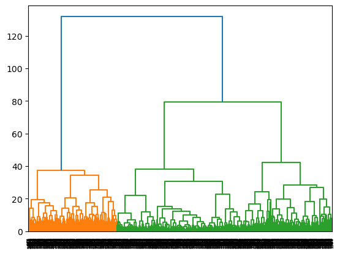

```python
linkage_data = linkage(df_scaled, method='ward', metric='euclidean')
dendrogram(linkage_data)

plt.show()
```

By observing the height in the dendrogram at which two clusters are merged, I have identified a 3 cluster solutions.

```python
hierarchical_cluster = AgglomerativeClustering(n_clusters=3, affinity='euclidean', linkage='ward')
labels = hierarchical_cluster.fit_predict(df_scaled)
```

```python
df["Cluster"] = labels
```

Now that our observations are assiged to their specific clusters, we will compute summary statistics to gain a comprehensive overview of the characteristics of each cluster. This will help us understand the distinct profiles or behaviors within each segment based on the variables we have selected.

```python
selected_columns.append('Cluster')
cluster_stats = df[selected_columns].groupby('Cluster').agg(['mean'])
```

```python
cluster_stats
```

| Cluster | Income mean | Totalkidsnum mean | Age mean | educationlevel mean | MntWines mean | MntFruits mean | MntMeatProducts mean | MntFishProducts mean | MntSweetProducts mean | MntGoldProds mean | NumDealsPurchases mean | NumWebPurchases mean | NumCatalogPurchases mean | NumStorePurchases mean | NumWebVisitsMonth mean |
| --- | --- | --- | --- | --- | --- | --- | --- | --- | --- | --- | --- | --- | --- | --- | --- |
| 0 | 54922.510067 | 1.196309 | 53.399329 | 3.416107 | 416.791946 | 17.092282 | 121.087248 | 23.357383 | 15.825503 | 58.087248 | 3.813758 | 5.924497 | 2.753356 | 6.840604 | 6.083893 |
| 1 | 73644.157627 | 0.318644 | 52.367797 | 2.877966 | 578.913559 | 66.720339 | 418.459322 | 96.652542 | 70.708475 | 72.389831 | 1.559322 | 5.384746 | 5.596610 | 8.540678 | 3.155932 |
| 2 | 33863.570060 | 1.227545 | 48.604790 | 2.908982 | 35.274251 | 4.468263 | 19.817964 | 6.049102 | 4.742515 | 13.695808 | 1.815569 | 1.926946 | 0.481437 | 3.138922 | 6.353293 |

### Cluster 0 Characteristics

-Middle Income -Have Kids -Mean age 53 years old -Spend mostly on Wines and Gold Products -Preferred purchase channel (Store > Web > Catalog) -Frequent vists to the company's webpage -Respond to deals

Customers in this segment are typically middle-income parents who prioritize spending on wines and gold products. They prefer purchasing both from stores and online via the company's website. They frequently visit the website and are responsive to various deals and promotions. An appropriate name for this customer segment is 'Savvy Parent Shoppers'.

### Cluster 1 Characteristics

-High Income -Little to no kids -Mean age 52 years old -Spend the most across all product categories -Preferred purchase channel (Store > Catalog > Web) -Low response to deals -Seldom visit the company's webpage

This customer segment drives significant sales for the grocery firm, consistently spending the most across all product categories. They frequently make purchases in-store and are the sole segment that regularly buys from the catalog. They rarely visit the company's website and show minimal responsiveness to deals and promotions. An appropriate name for this customer segment is 'Loyal Customers'.

### Cluster 2 Characteristics

-Low Income -Have Kids -Spent the lowest across all product categories -Preferred purchase channel (Store > Web > Catalog) -Low to moderate response to deals

This customer segment primarily consists of parents with lower income, spending less across all product categories. They predominantly make purchases through both the store and website channels. They show moderate responsiveness to deals and promotions. An appropriate name for this customer segment is 'low-income parents'.

```python
cluster_mapping = {0: 'Savvy Parent Shoppers', 1: 'Loyal Customers', 2: 'Low-income parents'}

# Replace the values in the DataFrame
df['Cluster'] = df['Cluster'].replace(cluster_mapping)
```

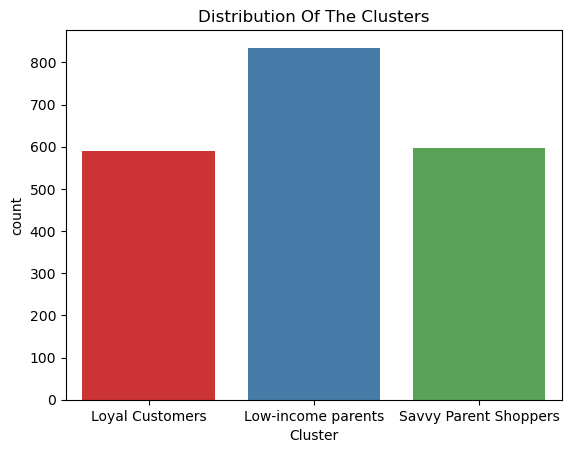

```python
pl = sns.countplot(x=df["Cluster"], palette='Set1')
pl.set_title("Distribution Of The Clusters")
plt.show()
```

The cluster seem to be fairly distributed with the 'Low-income parents' having the highest frequency.

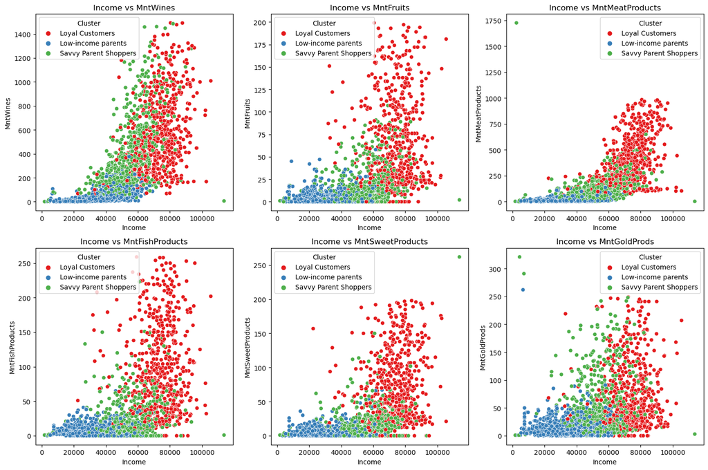

```python
plot_df = df[["Income",
             "MntWines",
             "MntFruits",
             "MntMeatProducts",
             "MntFishProducts",
             "MntSweetProducts",
             "MntGoldProds",
             "Cluster"]]


# List of spending categories
spending_categories = ["MntWines", "MntFruits", "MntMeatProducts", "MntFishProducts", "MntSweetProducts", "MntGoldProds"]

# Create six scatter plots
fig, axes = plt.subplots(2, 3, figsize=(15, 10))
axes = axes.flatten()

for i, category in enumerate(spending_categories):
    sns.scatterplot(data=plot_df, x='Income', y=category, hue='Cluster', palette='Set1', ax=axes[i])
    axes[i].set_title(f'Income vs {category}')
    axes[i].set_xlabel('Income')
    axes[i].set_ylabel(category)

plt.tight_layout()
plt.show()
```

We created scatter plots to visualize the relationship between customers' income and their spending across different product categories. There appears to be a positive correlation across all categories, indicating that customers with higher incomes tend to spend more. Additionally, we noticed that the 'Savy Parent Shoppers' segment shows particularly high spending in the wines and gold product categories.

It's plausible that deals and promotions are frequently targeted at wines and golds, explaining the higher spending by this segment, which is receptive to such promotions.

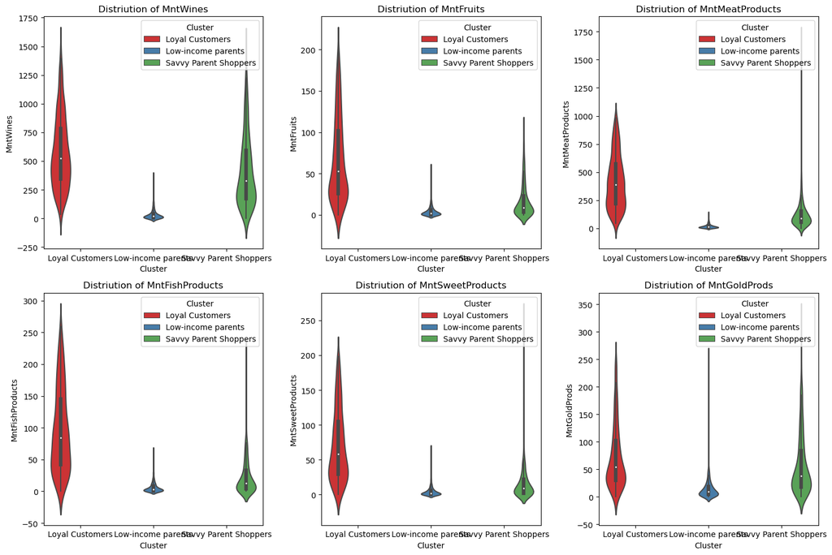

```python
fig, axes = plt.subplots(2, 3, figsize=(15, 10))
axes = axes.flatten()

for i, category in enumerate(spending_categories):
    sns.violinplot(x='Cluster', y= category, data=plot_df, hue='Cluster', palette='Set1', ax=axes[i])
    axes[i].set_title(f'Distriution of {category}')
    axes[i].set_xlabel('Cluster')
    axes[i].set_ylabel(category)

plt.tight_layout()
plt.show()
```

We generated multiple violin plots to visualise the distribution of amount spent for each product category by cluster.

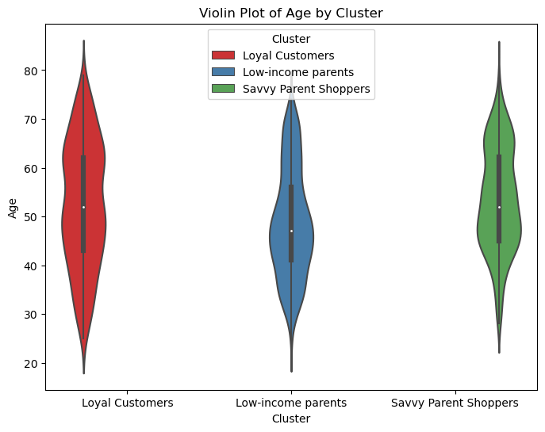

```python
plt.figure(figsize=(8, 6))
sns.violinplot(x='Cluster', y='Age', data=df, hue='Cluster', palette='Set1')
plt.title('Violin Plot of Age by Cluster')
plt.xlabel('Cluster')
plt.ylabel('Age')
plt.show()
```

The violin plot above reveals that the customers from different clusters generally belong to the same age group, with the segment of low-income parents being slightly younger than the other two segments.

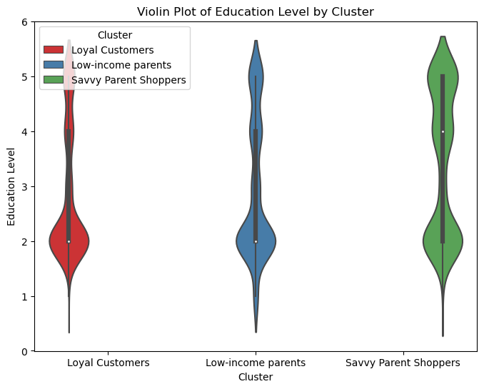

```python
plt.figure(figsize=(8, 6))
sns.violinplot(x='Cluster', y='educationlevel', data=df, hue='Cluster', palette='Set1')
plt.title('Violin Plot of Education Level by Cluster')
plt.xlabel('Cluster')
plt.ylabel('Education Level')
plt.show()
```

The Savvy Parent Shoppers appear to be the most educated, with a median education level at the master's degree level, whereas the other segments have a median education level at the undergraduate level.

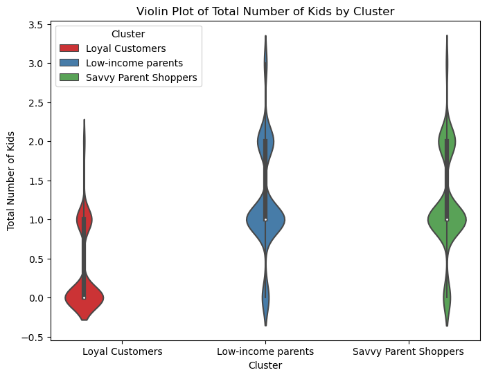

```python
plt.figure(figsize=(8, 6))
sns.violinplot(x='Cluster', y='Totalkidsnum', data=df, hue='Cluster', palette='Set1')
plt.title('Violin Plot of Total Number of Kids by Cluster')
plt.xlabel('Cluster')
plt.ylabel('Total Number of Kids')
plt.show()
```

The plot indicates that Loyal customers, as a group, are typically not parents.

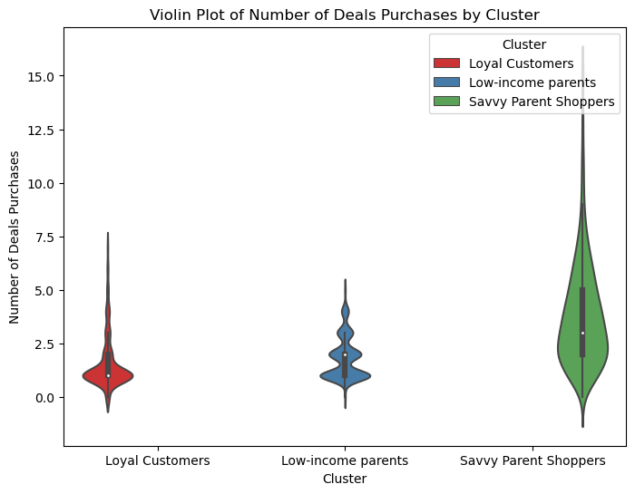

```python
plt.figure(figsize=(8, 6))
sns.violinplot(x='Cluster', y='NumDealsPurchases', data=df, hue='Cluster', palette='Set1')
plt.title('Violin Plot of Number of Deals Purchases by Cluster')
plt.xlabel('Cluster')
plt.ylabel('Number of Deals Purchases')
plt.show()
```

The plot indicates that Loyal customers show the lowest response to deals.

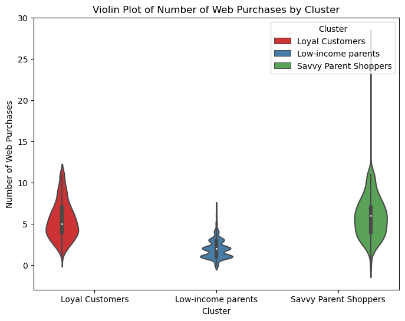

```python
plt.figure(figsize=(8, 6))
sns.violinplot(x='Cluster', y='NumWebPurchases', data=df, hue='Cluster', palette='Set1')
plt.title('Violin Plot of Number of Web Purchases by Cluster')
plt.xlabel('Cluster')
plt.ylabel('Number of Web Purchases')
plt.show()
```

## Is there a relationship between the number of web visits per month and the number of deals purchases?

Understanding whether the number of deals purchased is correlated with the number of website visits per month will help us determine if direct website traffic is an effective channel for promoting future deals.

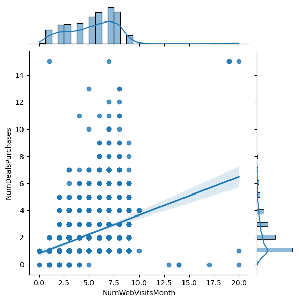

```python
sns.jointplot(x = 'NumWebVisitsMonth', y = 'NumDealsPurchases', data = df, kind = 'reg')
plt.show()
```

```python
x = df['NumWebVisitsMonth']
y = df['NumDealsPurchases']

x = sm.add_constant(x)

model = sm.OLS(y, x).fit()

print(model.summary())
```

```
                            OLS Regression Results
==============================================================================
Dep. Variable:      NumDealsPurchases   R-squared:                       0.132
Model:                            OLS   Adj. R-squared:                  0.132
Method:                 Least Squares   F-statistic:                     308.2
Date:                Mon, 17 Jun 2024   Prob (F-statistic):           2.54e-64
Time:                        16:41:32   Log-Likelihood:                -4013.1
No. Observations:                2021   AIC:                             8030.
Df Residuals:                    2019   BIC:                             8041.
Df Model:                           1
Covariance Type:            nonrobust
=====================================================================================
                        coef    std err          t      P>|t|      [0.025      0.975]
-------------------------------------------------------------------------------------
const                 0.8140      0.095      8.581      0.000       0.628       1.000
NumWebVisitsMonth     0.2839      0.016     17.555      0.000       0.252       0.316
==============================================================================
Omnibus:                      933.533   Durbin-Watson:                   2.018
Prob(Omnibus):                  0.000   Jarque-Bera (JB):             6724.813
Skew:                           2.041   Prob(JB):                         0.00
Kurtosis:                      10.950   Cond. No.                         14.5
==============================================================================

Notes:
[1] Standard Errors assume that the covariance matrix of the errors is correctly specified.
```

An R-squared value of 0.132 indicates a weak correlation between the number of web visits and the number of deals purchased, with web visits accounting for only 13.2% of the variation in deal purchases. This suggests that other important variables could enhance the explanatory power of the model.

However, the number of web visits is still a statistically significant predictor of the number of deals purchased, as indicated by a P-value less than 0.05 at a 95% confidence level. For each additional web visit, the number of deals purchased increases by 0.2839.

# Multiple Linear Regression Analysis

Through the MLR analysis, we aim to achieve the following objectives,

Quantifying the relationships between the dependent variable (Total amount spent) and each independent varaible, providing us insights into which factors have the most significant impact.

Identifying the most influential variables that drive changes in the dependent variable, enable us to make better decisions through target actions and resource allocation. We also want to assess the effectiveness of the model by understanding how various factors contributes to the outcome.

The independent variables selected for this analysis are the following,

Marital Status(Categorical Dummy Variable), Education level (Categorical Dummy Variable), Income (Continuous), Customer Days(Continuous), Age(Continuous)

```python
#To improve the interpretation of the model, we will convert the "educationlevel" variable from numeric to nominal categorical, creating dummy variables for our multiple linear regression (MLR) analysis.
education_mapping = {1: 'Basic', 2: 'Undergrad', 3: '2nd_Cycle', 4: 'Masters', 5: 'PHD'}

df['educationlevel'] = df['educationlevel'].replace(education_mapping)
```

```python
# Create a new column 'marital_status'.
df['marital_status'] = ''

for index, row in df.iterrows():
    # Check each binary indicator and assign the corresponding marital status
    if row['marital_Divorced'] == 1:
        df.at[index, 'marital_status'] = 'Divorced'
    elif row['marital_Married'] == 1:
        df.at[index, 'marital_status'] = 'Married'
    elif row['marital_Single'] == 1:
        df.at[index, 'marital_status'] = 'Single'
    elif row['marital_Together'] == 1:
        df.at[index, 'marital_status'] = 'Together'
    elif row['marital_Widow'] == 1:
        df.at[index, 'marital_status'] = 'Widow'
```

```python
# Create dummy variables for education level and marital_status.
df = pd.get_dummies(df, columns=["educationlevel", "marital_status"])

# 'educationlevel_Undergrad' and 'marital_status_Married' are chose as references.
df.drop(columns=['educationlevel_Undergrad', 'marital_status_Married'], inplace=True)
```

```python
df
```

|  | Income | Kidhome | Teenhome | Recency | MntWines | MntFruits | MntMeatProducts | MntFishProducts | MntSweetProducts | MntGoldProds | ... | Total_Mnt | Cluster | educationlevel_2nd_Cycle | educationlevel_Basic | educationlevel_Masters | educationlevel_PHD | marital_status_Divorced | marital_status_Single | marital_status_Together | marital_status_Widow |
| --- | --- | --- | --- | --- | --- | --- | --- | --- | --- | --- | --- | --- | --- | --- | --- | --- | --- | --- | --- | --- | --- |
| 0 | 58138.0 | 0 | 0 | 58 | 635 | 88 | 546 | 172 | 88 | 88 | ... | 1617 | Loyal Customers | False | False | False | False | False | True | False | False |
| 1 | 46344.0 | 1 | 1 | 38 | 11 | 1 | 6 | 2 | 1 | 6 | ... | 27 | Low-income parents | False | False | False | False | False | True | False | False |
| 2 | 71613.0 | 0 | 0 | 26 | 426 | 49 | 127 | 111 | 21 | 42 | ... | 776 | Loyal Customers | False | False | False | False | False | False | True | False |
| 3 | 26646.0 | 1 | 0 | 26 | 11 | 4 | 20 | 10 | 3 | 5 | ... | 53 | Low-income parents | False | False | False | False | False | False | True | False |
| 4 | 58293.0 | 1 | 0 | 94 | 173 | 43 | 118 | 46 | 27 | 15 | ... | 422 | Savvy Parent Shoppers | False | False | False | True | False | False | False | False |
| ... | ... | ... | ... | ... | ... | ... | ... | ... | ... | ... | ... | ... | ... | ... | ... | ... | ... | ... | ... | ... | ... |
| 2198 | 26816.0 | 0 | 0 | 50 | 5 | 1 | 6 | 3 | 4 | 3 | ... | 22 | Low-income parents | False | False | False | False | False | True | False | False |
| 2200 | 61223.0 | 0 | 1 | 46 | 709 | 43 | 182 | 42 | 118 | 247 | ... | 1341 | Loyal Customers | False | False | False | False | False | False | False | False |
| 2202 | 56981.0 | 0 | 0 | 91 | 908 | 48 | 217 | 32 | 12 | 24 | ... | 1241 | Loyal Customers | False | False | False | False | True | False | False | False |
| 2203 | 69245.0 | 0 | 1 | 8 | 428 | 30 | 214 | 80 | 30 | 61 | ... | 843 | Savvy Parent Shoppers | False | False | True | False | False | False | True | False |
| 2204 | 52869.0 | 1 | 1 | 40 | 84 | 3 | 61 | 2 | 1 | 21 | ... | 172 | Low-income parents | False | False | False | True | False | False | False | False |

2021 rows × 50 columns

```python
predictors = ["Income", "Age", "Totalkidsnum", "educationlevel_Basic", "educationlevel_Masters", "educationlevel_2nd_Cycle", "educationlevel_PHD", "Customer_Days", "marital_status_Single" , "marital_status_Divorced", "marital_status_Together", "marital_status_Widow"]
dependent_variable = "Total_Mnt"
```

```python
# Convert boolean dummy variables to integers
df[["educationlevel_Basic", "educationlevel_Masters", "educationlevel_2nd_Cycle", "educationlevel_PHD"]] = df[["educationlevel_Basic", "educationlevel_Masters", "educationlevel_2nd_Cycle", "educationlevel_PHD"]].astype(int)

df[["marital_status_Single" , "marital_status_Divorced", "marital_status_Together", "marital_status_Widow"]] = df[["marital_status_Single" , "marital_status_Divorced", "marital_status_Together", "marital_status_Widow"]].astype(int)
```

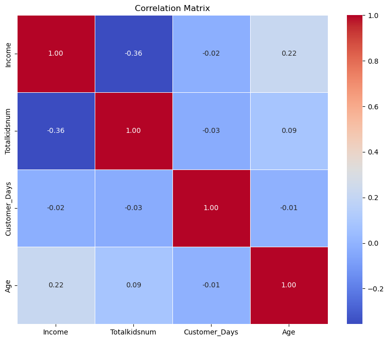

```python
correlation_matrix = df[["Income", "Totalkidsnum", "Customer_Days", "Age"]].corr()

# Plot correlation matrix
plt.figure(figsize=(10, 8))
sns.heatmap(correlation_matrix, annot=True, cmap='coolwarm', fmt=".2f", linewidths=0.5)
plt.title('Correlation Matrix')
plt.show()
```

We will generate a correlation matrix to identify any strong correlations between variables.

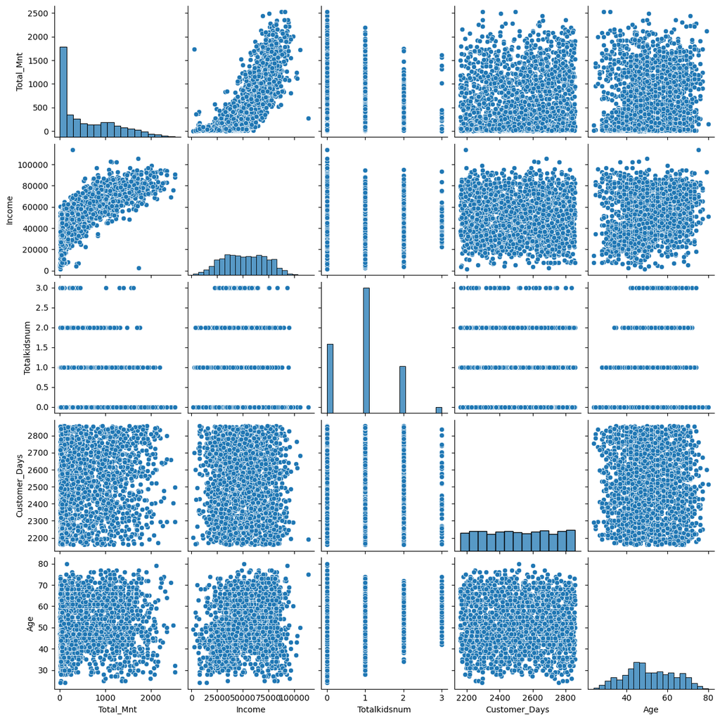

```python
sns.pairplot(df[["Total_Mnt", "Income", "Totalkidsnum", "Customer_Days", "Age"]])
```

```python
#Log Transform Total_Mnt variable.
df["log_Total_Mnt"] = np.log(df['Total_Mnt'])
df["sqrt_Total_Mnt"] = np.sqrt(df['Total_Mnt'])
```

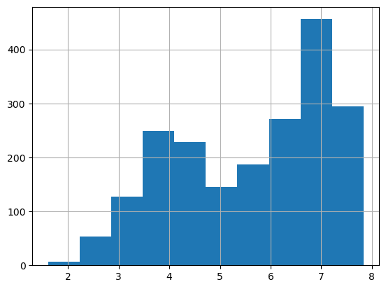

```python
df["log_Total_Mnt"].hist()
```

```python
dependent_variable = "log_Total_Mnt" #change to the transformed variable

# MLR analysis
X = df[predictors]
X = sm.add_constant(X)  # Add a constant (intercept) to the model
y = df[dependent_variable]

model = sm.OLS(y, X).fit()

print(model.summary())
```

```
                            OLS Regression Results
==============================================================================
Dep. Variable:          log_Total_Mnt   R-squared:                       0.756
Model:                            OLS   Adj. R-squared:                  0.755
Method:                 Least Squares   F-statistic:                     518.4
Date:                Mon, 17 Jun 2024   Prob (F-statistic):               0.00
Time:                        16:41:41   Log-Likelihood:                -2237.3
No. Observations:                2021   AIC:                             4501.
Df Residuals:                    2008   BIC:                             4574.
Df Model:                          12
Covariance Type:            nonrobust
============================================================================================
                               coef    std err          t      P>|t|      [0.025      0.975]
--------------------------------------------------------------------------------------------
const                       -0.8178      0.224     -3.659      0.000      -1.256      -0.379
Income                    5.479e-05    9.1e-07     60.228      0.000     5.3e-05    5.66e-05
Age                          0.0037      0.002      2.447      0.014       0.001       0.007
Totalkidsnum                -0.3346      0.024    -13.842      0.000      -0.382      -0.287
educationlevel_Basic        -0.0336      0.112     -0.300      0.764      -0.253       0.186
educationlevel_Masters       0.0057      0.046      0.122      0.903      -0.085       0.097
educationlevel_2nd_Cycle    -0.0496      0.059     -0.835      0.404      -0.166       0.067
educationlevel_PHD          -0.0224      0.042     -0.529      0.597      -0.105       0.061
Customer_Days                0.0015    8.1e-05     18.498      0.000       0.001       0.002
marital_status_Single       -0.0306      0.044     -0.698      0.485      -0.117       0.055
marital_status_Divorced     -0.0719      0.057     -1.264      0.206      -0.183       0.040
marital_status_Together     -0.0284      0.042     -0.679      0.497      -0.110       0.054
marital_status_Widow         0.0259      0.093      0.278      0.781      -0.157       0.209
==============================================================================
Omnibus:                       95.086   Durbin-Watson:                   1.939
Prob(Omnibus):                  0.000   Jarque-Bera (JB):              162.427
Skew:                          -0.375   Prob(JB):                     5.36e-36
Kurtosis:                       4.168   Cond. No.                     7.64e+05
==============================================================================

Notes:
[1] Standard Errors assume that the covariance matrix of the errors is correctly specified.
[2] The condition number is large, 7.64e+05. This might indicate that there are
strong multicollinearity or other numerical problems.
```

### Partial T-test

```python
vif_df = df[predictors]
```

```python
vif = pd.DataFrame()
vif["Variable"] = vif_df.columns
vif["VIF"] = pd.Series([variance_inflation_factor(vif_df.values, i) for i in range(vif_df.shape[1])])
print(vif)
```

```
                    Variable        VIF
0                     Income   9.270144
1                        Age  21.718314
2               Totalkidsnum   3.123860
3       educationlevel_Basic   1.138002
4     educationlevel_Masters   1.336258
5   educationlevel_2nd_Cycle   1.189235
6         educationlevel_PHD   1.456695
7              Customer_Days  25.447076
8      marital_status_Single   1.564453
9    marital_status_Divorced   1.282949
10   marital_status_Together   1.647295
11      marital_status_Widow   1.124318
```

I observe high VIF value for "Age" and "Customer_Days".

```python
predictors.remove("Customer_Days")
```

```python
vif_df4 = df[predictors]
vif = pd.DataFrame()
vif["Variable"] = vif_df4.columns
vif["VIF"] = pd.Series([variance_inflation_factor(vif_df4.values, i) for i in range(vif_df4.shape[1])])
print(vif)
```

```
                    Variable        VIF
0                     Income   7.751248
1                        Age  12.698733
2               Totalkidsnum   2.836052
3       educationlevel_Basic   1.067743
4     educationlevel_Masters   1.334043
5   educationlevel_2nd_Cycle   1.147246
6         educationlevel_PHD   1.456533
7      marital_status_Single   1.486653
8    marital_status_Divorced   1.276330
9    marital_status_Together   1.615602
10      marital_status_Widow   1.123162
```

```python
predictors.remove("Age")
```

```python
vif_df5 = df[predictors]
vif = pd.DataFrame()
vif["Variable"] = vif_df5.columns
vif["VIF"] = pd.Series([variance_inflation_factor(vif_df5.values, i) for i in range(vif_df5.shape[1])])
print(vif)
```

```
                   Variable       VIF
0                    Income  2.902212
1              Totalkidsnum  1.950610
2      educationlevel_Basic  1.031650
3    educationlevel_Masters  1.301565
4  educationlevel_2nd_Cycle  1.138781
5        educationlevel_PHD  1.425494
6     marital_status_Single  1.453858
7   marital_status_Divorced  1.239597
8   marital_status_Together  1.552481
9      marital_status_Widow  1.084126
```

We rerun the MLR analysis by removing variables that are highly correlated.

```python
#MLR analysis excluding highly correlated varaibles.
X = df[predictors]
X = sm.add_constant(X)
y = df[dependent_variable]

model = sm.OLS(y, X).fit()

print(model.summary())
```

```
                            OLS Regression Results
==============================================================================
Dep. Variable:          log_Total_Mnt   R-squared:                       0.714
Model:                            OLS   Adj. R-squared:                  0.712
Method:                 Least Squares   F-statistic:                     500.9
Date:                Mon, 17 Jun 2024   Prob (F-statistic):               0.00
Time:                        16:44:28   Log-Likelihood:                -2399.0
No. Observations:                2021   AIC:                             4820.
Df Residuals:                    2010   BIC:                             4882.
Df Model:                          10
Covariance Type:            nonrobust
============================================================================================
                               coef    std err          t      P>|t|      [0.025      0.975]
--------------------------------------------------------------------------------------------
const                        3.1183      0.072     43.342      0.000       2.977       3.259
Income                     5.51e-05    9.6e-07     57.422      0.000    5.32e-05     5.7e-05
Totalkidsnum                -0.3370      0.026    -13.042      0.000      -0.388      -0.286
educationlevel_Basic         0.0597      0.121      0.493      0.622      -0.178       0.297
educationlevel_Masters      -0.0179      0.050     -0.356      0.722      -0.116       0.080
educationlevel_2nd_Cycle    -0.0509      0.064     -0.794      0.427      -0.177       0.075
educationlevel_PHD          -0.0381      0.046     -0.836      0.403      -0.128       0.051
marital_status_Single       -0.0353      0.047     -0.745      0.456      -0.128       0.058
marital_status_Divorced     -0.0416      0.061     -0.678      0.498      -0.162       0.079
marital_status_Together     -0.0204      0.045     -0.451      0.652      -0.109       0.068
marital_status_Widow         0.1151      0.099      1.158      0.247      -0.080       0.310
==============================================================================
Omnibus:                       44.560   Durbin-Watson:                   2.002
Prob(Omnibus):                  0.000   Jarque-Bera (JB):               61.966
Skew:                          -0.247   Prob(JB):                     3.50e-14
Kurtosis:                       3.701   Cond. No.                     3.93e+05
==============================================================================

Notes:
[1] Standard Errors assume that the covariance matrix of the errors is correctly specified.
[2] The condition number is large, 3.93e+05. This might indicate that there are
strong multicollinearity or other numerical problems.
```

```python
#We remove the remaining variables that are not significant.
predictors = ["Income", "Totalkidsnum"]

X = df[predictors]
X = sm.add_constant(X)
y = df[dependent_variable]

model = sm.OLS(y, X).fit()

print(model.summary())
```

```
                            OLS Regression Results
==============================================================================
Dep. Variable:          log_Total_Mnt   R-squared:                       0.713
Model:                            OLS   Adj. R-squared:                  0.713
Method:                 Least Squares   F-statistic:                     2507.
Date:                Mon, 17 Jun 2024   Prob (F-statistic):               0.00
Time:                        16:44:32   Log-Likelihood:                -2401.1
No. Observations:                2021   AIC:                             4808.
Df Residuals:                    2018   BIC:                             4825.
Df Model:                           2
Covariance Type:            nonrobust
================================================================================
                   coef    std err          t      P>|t|      [0.025      0.975]
--------------------------------------------------------------------------------
const            3.0988      0.063     49.391      0.000       2.976       3.222
Income        5.498e-05   9.13e-07     60.208      0.000    5.32e-05    5.68e-05
Totalkidsnum    -0.3395      0.025    -13.393      0.000      -0.389      -0.290
==============================================================================
Omnibus:                       46.595   Durbin-Watson:                   2.000
Prob(Omnibus):                  0.000   Jarque-Bera (JB):               64.727
Skew:                          -0.257   Prob(JB):                     8.81e-15
Kurtosis:                       3.711   Cond. No.                     2.05e+05
==============================================================================

Notes:
[1] Standard Errors assume that the covariance matrix of the errors is correctly specified.
[2] The condition number is large, 2.05e+05. This might indicate that there are
strong multicollinearity or other numerical problems.
```

The model suggests the following relationships: Income: Positively correlated with the total amount spent. For every 1 unit increase in income, the amount spent increases by 0.005%. Total Number of Kids: Negatively correlated with the total amount spent. For every 1 unit increase in the total number of kids, the amount spent decreases by 33.95%.

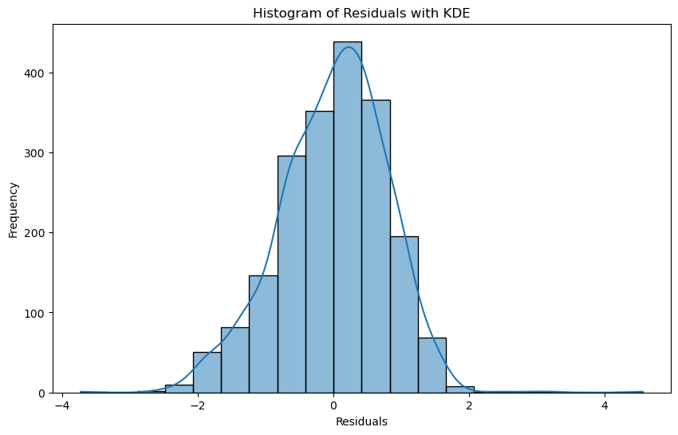

```
Mean of residuals: 0.0000
```

```python
residuals = model.resid
mean_residuals = np.mean(residuals)

plt.figure(figsize=(10, 6))
sns.histplot(residuals, bins=20, kde=True, edgecolor='black')

plt.xlabel('Residuals')
plt.ylabel('Frequency')
plt.title('Histogram of Residuals with KDE')
plt.show()

print(f"Mean of residuals: {mean_residuals:.4f}")
```

A residual histogram is plotted to examine if the model violates the normality assumptions of Multiple Linear Regression (MLR). The histogram shows that the residuals are normally distributed with a mean close to zero. Hence, I conclude that the model does not violate the normality assumption.

```python
# Standardize the variables
scaler = StandardScaler()
X_scaled = scaler.fit_transform(df[predictors])  # Standardize predictor variables
y_scaled = scaler.fit_transform(df["Total_Mnt"].values.reshape(-1, 1))

# Fit the regression model using standardized variables
model = sm.OLS(y_scaled, sm.add_constant(X_scaled)).fit()

print(model.summary())
```

```
                            OLS Regression Results
==============================================================================
Dep. Variable:                      y   R-squared:                       0.724
Model:                            OLS   Adj. R-squared:                  0.723
Method:                 Least Squares   F-statistic:                     2643.
Date:                Mon, 17 Jun 2024   Prob (F-statistic):               0.00
Time:                        16:45:16   Log-Likelihood:                -1567.9
No. Observations:                2021   AIC:                             3142.
Df Residuals:                    2018   BIC:                             3159.
Df Model:                           2
Covariance Type:            nonrobust
==============================================================================
                 coef    std err          t      P>|t|      [0.025      0.975]
------------------------------------------------------------------------------
const      -2.307e-17      0.012  -1.97e-15      1.000      -0.023       0.023
x1             0.7320      0.013     58.462      0.000       0.707       0.757
x2            -0.2451      0.013    -19.571      0.000      -0.270      -0.221
==============================================================================
Omnibus:                      163.583   Durbin-Watson:                   1.944
Prob(Omnibus):                  0.000   Jarque-Bera (JB):              409.049
Skew:                           0.466   Prob(JB):                     1.50e-89
Kurtosis:                       4.997   Cond. No.                         1.45
==============================================================================

Notes:
[1] Standard Errors assume that the covariance matrix of the errors is correctly specified.
```

Since the predictors are using different measures, we will scale them and rerun the model to examine the standardized partial regression coefficient of each variable. The importance of the variables is as follows: Income > Number of Kids.

# ANOVA

n the upcoming ANOVA analysis, our goal is to determine whether the total amount spent varies depending on education level and marital status. Additionally, we will examine whether there is a significant interaction between these two variables.

```python
#We will create a new categorical variable for education level.
df["educationlevel"] = 0

def assign_education_level(row):
    if row['education_PhD'] == 1:
        return 5
    elif row['education_Master'] == 1:
        return 4
    elif row['education_2n Cycle'] == 1:
        return 3
    elif row['education_Graduation'] == 1:
        return 2
    elif row['education_Basic'] == 1:
        return 1
    else:
        return 0

df['educationlevel'] = df.apply(assign_education_level, axis=1)
```

```python
# Create a new column 'marital_status' using if-else statements. We Check each binary indicator and assign the corresponding marital status.
df['marital_status'] = ''

for index, row in df.iterrows():

    if row['marital_Divorced'] == 1:
        df.at[index, 'marital_status'] = 'Divorced'
    elif row['marital_Married'] == 1:
        df.at[index, 'marital_status'] = 'Married'
    elif row['marital_Single'] == 1:
        df.at[index, 'marital_status'] = 'Single'
    elif row['marital_Together'] == 1:
        df.at[index, 'marital_status'] = 'Together'
    elif row['marital_Widow'] == 1:
        df.at[index, 'marital_status'] = 'Widow'
```

```python
education_mapping = {1: 'Basic', 2: 'Undergrad', 3: '2nd_Cycle', 4: 'Masters', 5: 'PHD'}

# Replace the values in the DataFrame
df['educationlevel'] = df['educationlevel'].replace(education_mapping)
```

```python
df
```

|  | Income | Kidhome | Teenhome | Recency | MntWines | MntFruits | MntMeatProducts | MntFishProducts | MntSweetProducts | MntGoldProds | ... | educationlevel_Masters | educationlevel_PHD | marital_status_Divorced | marital_status_Single | marital_status_Together | marital_status_Widow | log_Total_Mnt | sqrt_Total_Mnt | educationlevel | marital_status |
| --- | --- | --- | --- | --- | --- | --- | --- | --- | --- | --- | --- | --- | --- | --- | --- | --- | --- | --- | --- | --- | --- |
| 0 | 58138.0 | 0 | 0 | 58 | 635 | 88 | 546 | 172 | 88 | 88 | ... | 0 | 0 | 0 | 1 | 0 | 0 | 7.388328 | 40.211939 | Undergrad | Single |
| 1 | 46344.0 | 1 | 1 | 38 | 11 | 1 | 6 | 2 | 1 | 6 | ... | 0 | 0 | 0 | 1 | 0 | 0 | 3.295837 | 5.196152 | Undergrad | Single |
| 2 | 71613.0 | 0 | 0 | 26 | 426 | 49 | 127 | 111 | 21 | 42 | ... | 0 | 0 | 0 | 0 | 1 | 0 | 6.654153 | 27.856777 | Undergrad | Together |
| 3 | 26646.0 | 1 | 0 | 26 | 11 | 4 | 20 | 10 | 3 | 5 | ... | 0 | 0 | 0 | 0 | 1 | 0 | 3.970292 | 7.280110 | Undergrad | Together |
| 4 | 58293.0 | 1 | 0 | 94 | 173 | 43 | 118 | 46 | 27 | 15 | ... | 0 | 1 | 0 | 0 | 0 | 0 | 6.045005 | 20.542639 | PHD | Married |
| ... | ... | ... | ... | ... | ... | ... | ... | ... | ... | ... | ... | ... | ... | ... | ... | ... | ... | ... | ... | ... | ... |
| 2198 | 26816.0 | 0 | 0 | 50 | 5 | 1 | 6 | 3 | 4 | 3 | ... | 0 | 0 | 0 | 1 | 0 | 0 | 3.091042 | 4.690416 | Undergrad | Single |
| 2200 | 61223.0 | 0 | 1 | 46 | 709 | 43 | 182 | 42 | 118 | 247 | ... | 0 | 0 | 0 | 0 | 0 | 0 | 7.201171 | 36.619667 | Undergrad | Married |
| 2202 | 56981.0 | 0 | 0 | 91 | 908 | 48 | 217 | 32 | 12 | 24 | ... | 0 | 0 | 1 | 0 | 0 | 0 | 7.123673 | 35.227830 | Undergrad | Divorced |
| 2203 | 69245.0 | 0 | 1 | 8 | 428 | 30 | 214 | 80 | 30 | 61 | ... | 1 | 0 | 0 | 0 | 1 | 0 | 6.736967 | 29.034462 | Masters | Together |
| 2204 | 52869.0 | 1 | 1 | 40 | 84 | 3 | 61 | 2 | 1 | 21 | ... | 0 | 1 | 0 | 0 | 0 | 0 | 5.147494 | 13.114877 | PHD | Married |

2021 rows × 54 columns

```python
df["educationlevel"].value_counts()
```

```
educationlevel
Undergrad    1015
PHD           439
Masters       335
2nd_Cycle     183
Basic          49
Name: count, dtype: int64
```

```python
df["marital_status"].value_counts()
```

```
marital_status
Married     785
Together    509
Single      443
Divorced    214
Widow        70
Name: count, dtype: int64
```

We examine the frequency to ensure that we have enough data for each group.

```python
model = ols('Total_Mnt ~ educationlevel * marital_status', data=df).fit()

anova_table = sm.stats.anova_lm(model, typ=2)
print(anova_table)
```

```
                                     sum_sq      df          F        PR(>F)
educationlevel                 1.711977e+07     4.0  12.030672  1.157035e-09
marital_status                 1.481430e+06     4.0   1.041054  3.845305e-01
educationlevel:marital_status  4.204313e+06    16.0   0.738630  7.559695e-01
Residual                       7.100820e+08  1996.0        NaN           NaN
```

### F-Test

Null Hypothesis: The mean total amount spent is the same across different level of the predictor. Alternative Hypothesis: The mean total amount spent is different across different level of the predictor.

The analysis indicates that the mean amount spent varies significantly across different levels of education, as evidenced by the statistical significance of the F-statistic (P-value < 0.05, 95% confidence interval).

Marital Status: The P-value associated with marital status is 0.38, which is greater than 0.05. Therefore, there is insufficient evidence to reject the null hypothesis. It suggests that the mean amount spent does not differ significantly across different marital status categories. Interaction Effect: The P-value for the interaction between education level and marital status is 0.75. This indicates that there is no significant interaction effect between education level and marital status on the total amount spent.

In summary: Education level significantly affects the mean amount spent. Marital status does not show a significant effect on the mean amount spent. There is no significant interaction between education level and marital status regarding the total amount spent.

### How the Total amount spent differ across different level of educationlevel?

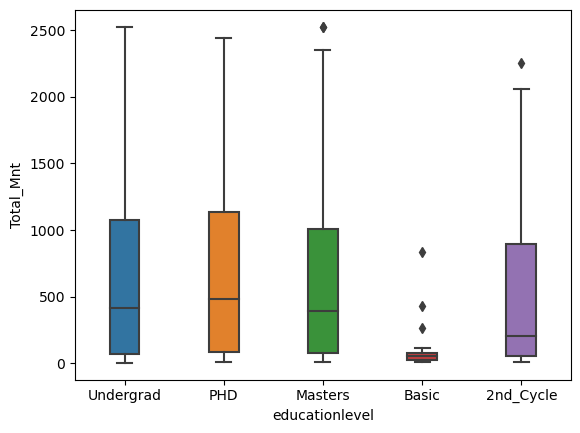

```python
sns.boxplot(data = df, x = 'educationlevel', y = 'Total_Mnt', width = 0.3)
```

The side-by-side boxplot reveals that customers with basic education level spent the least, while those with Undergrad, Masters and PHD qualifications tend to spend more.

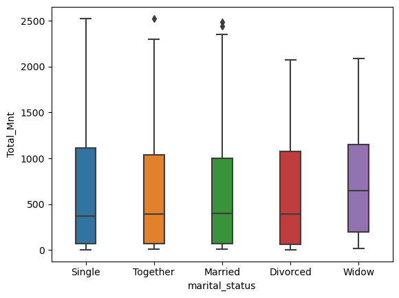

```python
sns.boxplot(data = df, x = 'marital_status', y = 'Total_Mnt', width = 0.3)
```

The box plot depicting the total amount spent by marital status suggests that widows tend to spend more. However, according to the ANOVA analysis, this difference is not statistically significant.